# Income, Energy Consumption and CO2-Emissions with R Notebook

SAB

## Introduction

1. Visualizing in R the relationships between Income, Energy consumption and CO2-emission,
2. Incrementing the dataset with further Energy- and CO2-emissions related variables, and thereafter expand the previous correlation matrix with additional Income-, Energy- and CO2-emissions-related variables,
3. Performing a Cluster Analysis based on a Multiple Factorial Analysis (MFA), a method that aims at synthesizing the information from all available data on Income, Energy and CO2-emissions.
4. Visualizing the results from the Cluster Analysis on ArcGIS.

The considered dataset was used in an earlier project on *Sustainable Energy Consumption* - hence not up to date - and was sourced from the World Bank.

## Premilimary Illustrations

To illustrate the revolving idea behind how some variables relate to each others, i.e. the notion of relationships or correlation *(sammenhæng)*, let’s start these 2 common examples found on the net.

Consider first the amount of limonade sold in function of the day’s temperature.

```r
sales <- data.frame(c(14.2, 16.4, 11.9, 15.2, 18.5, 22.1, 19.4, 25.1, 23.4, 18.1, 22.6, 17.2),
                    c(215, 325, 185, 332, 406, 522, 412, 614, 544, 421, 445, 408))
colnames(sales) <- c("Temperature (C)","Limonade Sales (Quantity)")
sales
```

| Temperature (C) | Limonade Sales (Quantity) |
| --- | --- |
| 14.2 | 215 |
| 16.4 | 325 |
| 11.9 | 185 |
| 15.2 | 332 |
| 18.5 | 406 |
| 22.1 | 522 |
| 19.4 | 412 |
| 25.1 | 614 |
| 23.4 | 544 |
| 18.1 | 421 |

[output cut: 2 more lines]

The values can be represented graphically as below.

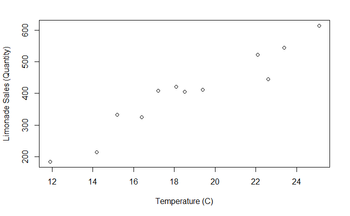

```r
plot(sales)
```

As can be seen, there seems to be a relationship between the amount of limonade sold and the temperature of the day, and a positive one.

In contrast, consider the amount of gazoline left in the tank of a car as the car travels a certain distance.

```r
tankLevel <- data.frame(c(0, 50, 150, 275, 350, 425, 540, 680, 700, 750),
                    c(15, 14, 12, 9.5, 8, 6.5, 4.2, 1.4, 1, 0))
colnames(tankLevel) <- c("Distance Travelled (km)","Gazoline Level (Quantity)")
tankLevel
```

| Distance Travelled (km) | Gazoline Level (Quantity) |
| --- | --- |
| 0 | 15.0 |
| 50 | 14.0 |
| 150 | 12.0 |
| 275 | 9.5 |
| 350 | 8.0 |
| 425 | 6.5 |
| 540 | 4.2 |
| 680 | 1.4 |
| 700 | 1.0 |
| 750 | 0.0 |

Graphically,

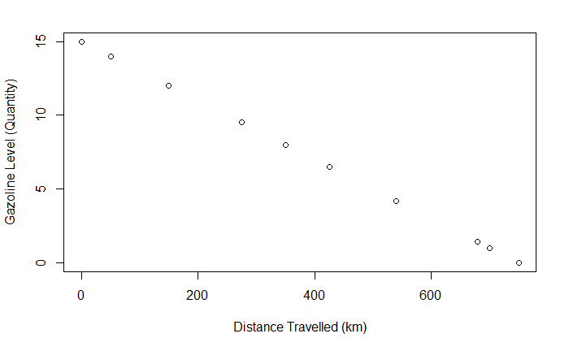

```r
plot(tankLevel)
```

Again, there appears to be a relationship between the amount of distance travelled and the level of gazoline in the tank of the car. Although this time, even more clearly, the graph demonstrates a negative relationship.

## Sustainable Energy Consumption

Now that the idea of relationship, or *correlation*, has been introduced, let’s shift back to the analysis considered at the beginning of the document. Among the questions that the analysis will try to answer, here are a few ones:

- Do average income, energy consumption and CO2-emissions of the countries of the world relate to each other?
- Do these different patterns of relationship also hold for other income-, energy- and CO2-emissions-related variables?
- Given a region or income level, how (dis)similar are countries in terms of Energy Consumption and CO2-emissions?

The analysis will be carried out in R and requires the use of the following packages (a collection of many functions):

```r
library(tidyverse)
library(PerformanceAnalytics)
library(gdata)
library(FactoMineR)
library(missMDA)
library(sp)
library(arcgisbinding)
```

To start, let’s read the available data on Income, Energy Consumption and CO2-emissions.

```r
Energy_comp = read.csv("3_TidyData/EnergyCompleted_Final.csv",
                       header=TRUE,sep=",", dec=".",
                       row.names = 1)
dim(Energy_comp)
```

```
[1] 147  18
```

As can be seen, the data consists of 147 countries of the world, the different regions/categories they belong to and the 3 afore-mentioned variable groups with 18 columns in total.

Let’s have a preview of the dataset:

```r
print(Energy_comp, 10)
```

|  | Country.Name | Region | Income.Group | Population | GDP..Mio.USD. | GDP.per.capita | HDI | Electricity.Consumption.per.capita..kWh | Fossil.fuel.energy.consumption..pct..of.total. | Electricity.production.from.oil.sources..pct..of.total. | Electricity.production.from.oil.gas.coal.sources..pct.of.total. | Electricity.production.from.hydroelectric.sources..pct.of.total. | Electricity.production.from.renewables.sources...excl..hydroelectric..pct.of.total. | Alternative.and.nuclear.energy..pct..of.total.energy.use. | Energy.use.per.capita..kg.oil.eq. | CO2.emissions..kt. | CO2.emissions..tons.per.capita. | CO2.emissions.from.transport..pct.of.total.fuel.combustion. |
| --- | --- | --- | --- | --- | --- | --- | --- | --- | --- | --- | --- | --- | --- | --- | --- | --- | --- | --- |
| AFG | Afghanistan | South Asia | Low income | 34656032 | 65142.8 | 1802.700 | 0.4790000 | 10.0000 | 56.31438 | 24.65847 | 57.28404 | 37.86226 | 3.689814 | 5.081635 | 50.0000 | 9809.23 | 0.300000 | 39.70712 |
| AGO | Angola | Sub-Saharan Africa | Lower middle income | 28813463 | 186327.0 | 5984.600 | 0.5330000 | 312.4800 | 48.28000 | 46.82000 | 46.82000 | 53.18000 | 0.000000 | 2.950000 | 545.0400 | 34763.16 | 1.290000 | 43.99000 |
| ALB | Albania | Europe & Central Asia | Upper middle income | 2876101 | 34126.4 | 11359.200 | 0.7640000 | 2309.3700 | 61.42000 | 0.00000 | 0.00000 | 100.00000 | 0.000000 | 17.920000 | 808.4600 | 5716.85 | 1.980000 | 59.95000 |
| ARE | United Arab Emirates | Middle East & North Africa | High income | 9269612 | 672419.6 | 67133.100 | 0.8400000 | 11263.5300 | 99.81000 | 1.34000 | 99.73000 | 0.00000 | 0.270000 | 0.100000 | 7769.2300 | 211369.55 | 23.300000 | 21.04000 |
| ARG | Argentina | Latin America & Caribbean | Upper middle income | 43847430 | 876012.1 | 18489.400 | 0.8270000 | 3052.3800 | 88.54000 | 13.83000 | 64.39000 | 29.04000 | 2.500000 | 5.880000 | 2015.1900 | 204024.55 | 4.750000 | 24.17000 |
| ARM | Armenia | Europe & Central Asia | Lower middle income | 2924816 | 25884.4 | 8190.200 | 0.7430000 | 1965.7800 | 74.56000 | 0.00000 | 42.44000 | 25.70000 | 0.050000 | 27.510000 | 1018.0700 | 5529.84 | 1.900000 | 27.78000 |
| AUS | Australia | East Asia & Pacific | High income | 24127159 | 1128908.0 | 44260.600 | 0.9390000 | 10059.2100 | 93.39000 | 2.02000 | 85.09000 | 7.41000 | 7.500000 | 2.550000 | 5328.2200 | 361261.84 | 15.370000 | 24.74000 |
| AUT | Austria | Europe & Central Asia | High income | 8747358 | 443005.0 | 44438.700 | 0.8930000 | 8360.5200 | 64.90000 | 0.99000 | 17.73000 | 66.57000 | 14.560000 | 12.870000 | 3765.4300 | 58712.34 | 6.870000 | 36.62000 |
| AZE | Azerbaijan | Europe & Central Asia | Upper middle income | 9762274 | 168713.8 | 16001.300 | 0.7590000 | 2202.3900 | 98.37000 | 0.16000 | 94.02000 | 5.26000 | 0.370000 | 0.780000 | 1502.0800 | 37487.74 | 3.930000 | 24.49000 |
| BDI | Burundi | Sub-Saharan Africa | Low income | 10524117 | 8201.1 | 721.200 | 0.4040000 | 10.0000 | 55.73222 | 27.22136 | 59.32039 | 37.62264 | 2.937671 | 3.303454 | 50.0000 | 440.04 | 0.040000 | 40.07004 |

[output cut: 137 more lines]

A summary of the dataset follows:

```r
print(summary(Energy_comp))
```

```
      Country.Name                        Region                Income.Group
 Namibia    :  2   East Asia & Pacific       :17   High income        :46
 Afghanistan:  1   Europe & Central Asia     :47   Low income         :23
 Albania    :  1   Latin America & Caribbean :23   Lower middle income:36
 Algeria    :  1   Middle East & North Africa:17   Upper middle income:42
 Angola     :  1   North America             : 2
 Argentina  :  1   South Asia                : 7
 (Other)    :140   Sub-Saharan Africa        :34
   Population        GDP..Mio.USD.      GDP.per.capita        HDI
 Min.   :3.195e+04   Min.   :     100   Min.   :   100   Min.   :0.3520
 1st Qu.:4.733e+06   1st Qu.:   38279   1st Qu.:  5219   1st Qu.:0.6115
 Median :1.065e+07   Median :  153199   Median : 13921   Median :0.7360
 Mean   :4.801e+07   Mean   :  796355   Mean   : 19788   Mean   :0.7100
 3rd Qu.:3.547e+07   3rd Qu.:  510809   3rd Qu.: 26569   3rd Qu.:0.8285
 Max.   :1.379e+09   Max.   :21450968   Max.   :118207   Max.   :0.9490

 Electricity.Consumption.per.capita..kWh Fossil.fuel.energy.consumption..pct..of.total.
 Min.   :   10.0                         Min.   :  5.36
 1st Qu.:  579.2                         1st Qu.: 54.28
 Median : 2202.4                         Median : 67.99
 Mean   : 3911.1                         Mean   : 65.89
 3rd Qu.: 5032.5                         3rd Qu.: 85.48
 Max.   :53832.5                         Max.   :100.00

 Electricity.production.from.oil.sources..pct..of.total.
 Min.   : 0.00
 1st Qu.: 0.35
 Median : 2.84
 Mean   :15.04
 3rd Qu.:22.68
 Max.   :99.46

 Electricity.production.from.oil.gas.coal.sources..pct.of.total.
 Min.   :  0.00
 1st Qu.: 38.20
 Median : 58.02
 Mean   : 57.88
 3rd Qu.: 86.47
 Max.   :100.00

```

[output cut: 24 more lines]

```
 Energy.use.per.capita..kg.oil.eq. CO2.emissions..kt. CO2.emissions..tons.per.capita.
 Min.   :   50.0                   Min.   :      50   Min.   : 0.010
 1st Qu.:  542.3                   1st Qu.:    6302   1st Qu.: 0.840
 Median : 1337.4                   Median :   26450   Median : 3.050
 Mean   : 2213.2                   Mean   :  224420   Mean   : 4.786
 3rd Qu.: 2771.2                   3rd Qu.:   95844   3rd Qu.: 6.220
 Max.   :18562.7                   Max.   :10291927   Max.   :45.420

 CO2.emissions.from.transport..pct.of.total.fuel.combustion.
 Min.   : 3.54
 1st Qu.:23.60
 Median :34.78
 Mean   :34.05
 3rd Qu.:40.51
 Max.   :96.78
```

**PS**: the existence of missing values for some variables was dealt with imputation methods from the package *missMDA*. Suffice to write here that the original dataset was trimmed of some countries that lack many values, while at the same time, 37 countries were kept for the analysis by imputing some of their missing values using the correlation structure of the dataset. Refer to this [App](https://arcg.is/uW4Ky) to compare the analysis with complete observations (110) and the one based on the augmented dataset (the current one) with imputed observations (147).

## Simple correlations from the lecture’s dataset

With this dataset, one can visualize the few correlations introduced in the [Google Sheets Document](https://docs.google.com/spreadsheets/d/1NZpys5yniDyOuUPxV7JKWkcTP-FUZL1esZSvUitZPd0/edit?usp=sharing). This is done with the package *PerformanceAnalytics* as follows.

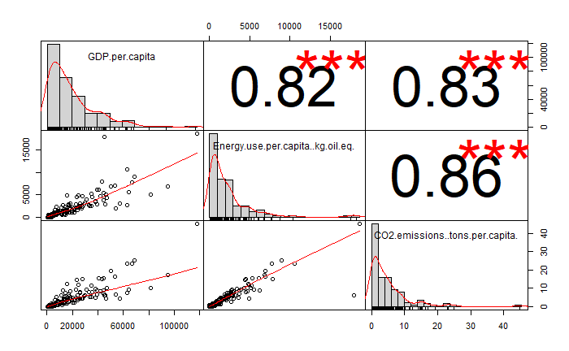

```r
chart.Correlation(Energy_comp[,c(6,15,17)], histogram=TRUE, pch=19)
```

Focusing first on the scatterplots, the graphical matrix could be read as one read for example a multiplication table, that is reading the rows first and then the columns: There, were the row belonging to *Energy Use per Capita* meets the column of *GDP per Capita*, the scatter-plot suggests a rather pronounced correlation between these 2 variables, although the correlation between *Energy Use per Capita* and *CO2 Emissions per Capita* appears to be slightly more significant. Not surprisingly given the well-known fact that fossile fuels still account for about 80 pct. of total energy consumed on the global level, far ahead of the share of renewable energy sources (around 10 pct.) as discussed during the lectures.

The 3 scatterplots can be drawn once more, this time visualizing the income groups each country (point) pertains to:

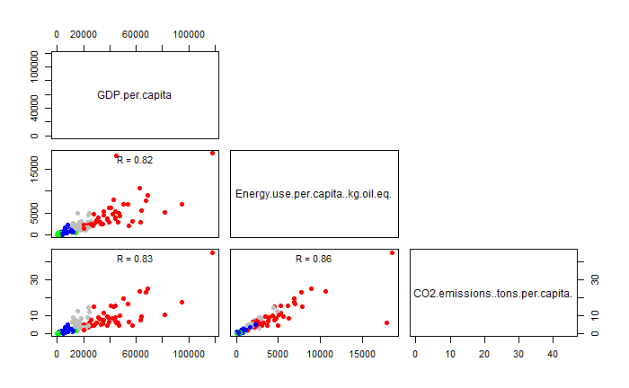

```r
lower.panel<-function(x, y){
  points(x,y, pch=19, col=c("red", "green", "blue", "grey")[Energy_comp$Income.Group])
  r <- round(cor(x, y), digits=2)
  txt <- paste0("R = ", r)
  usr <- par("usr"); on.exit(par(usr))
  par(usr = c(0, 1, 0, 1))
  text(0.5, 0.9, txt)
}
pairs(Energy_comp[,c(6,15,17)], upper.panel = NULL,
      lower.panel = lower.panel)
```

**PS**: The colour conventions are:

- **Red** for *high income* countries
- **Green** for *low income* countries
- **Blue** for *lower middle income* countries
- **Grey** for *upper middle income* countries

## Extended Correlation Structure

In the same fashion, one can expand the correlation matrix to include the remainder of the continuous variables at hand:

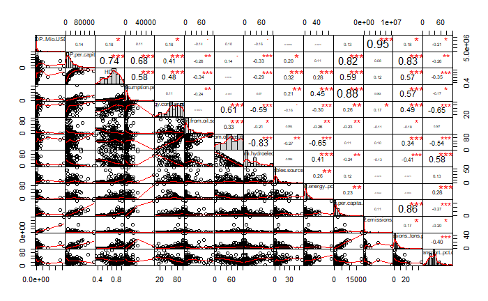

```r
chart.Correlation(Energy_comp[,c(5:18)], histogram=TRUE, pch=19)
```

Given the difficulty to distinguish between the details in such a graphical illustration, one can list the strongest correlations among all variables. This have been carried out in the next code chunk. In passing, note that the strongest relationships in the matrix are suggested by the number of red stars (3 means likelier relationships) or the numerical value of the correlation coefficient (stronger correlations where the coefficient is closer to 1 in absolute terms). Any biasing effects from outliers have been ignored.

```r
corm <- cor(Energy_comp[,c(5:18)])
corm[lower.tri(corm)] <- 0
corm[lower.tri(corm,diag=TRUE)] <- 0
cor <- as.data.frame(as.table(corm))
high<-subset(cor, abs(Freq) > 0.6)
as.matrix(high[order(-high[,3]),])
```

```
    Var1
155 "GDP..Mio.USD."
144 "Electricity.Consumption.per.capita..kWh"
179 "Energy.use.per.capita..kg.oil.eq."
170 "GDP.per.capita"
142 "GDP.per.capita"
30  "GDP.per.capita"
44  "GDP.per.capita"
89  "Fossil.fuel.energy.consumption..pct..of.total."
187 "Fossil.fuel.energy.consumption..pct..of.total."
133 "Electricity.production.from.oil.gas.coal.sources..pct.of.total."
105 "Electricity.production.from.oil.gas.coal.sources..pct.of.total."
    Var2                                                               Freq
155 "CO2.emissions..kt."                                               " 0.9527348"
144 "Energy.use.per.capita..kg.oil.eq."                                " 0.8760625"
179 "CO2.emissions..tons.per.capita."                                  " 0.8594627"
170 "CO2.emissions..tons.per.capita."                                  " 0.8343659"
142 "Energy.use.per.capita..kg.oil.eq."                                " 0.8151981"
30  "HDI"                                                              " 0.7420396"
44  "Electricity.Consumption.per.capita..kWh"                          " 0.6840740"
89  "Electricity.production.from.oil.gas.coal.sources..pct.of.total."  " 0.6123586"
187 "CO2.emissions.from.transport..pct.of.total.fuel.combustion."      "-0.6460173"
133 "Alternative.and.nuclear.energy..pct..of.total.energy.use."        "-0.6515375"
105 "Electricity.production.from.hydroelectric.sources..pct.of.total." "-0.8331979"
```

The correlation coefficients are arranged in descending order, and the ones of interest are those that are closest to 1 in absolute values.

Hence, there seems to be further relevant correlations among the variables from the extended dataset. To name a few …

- On the positive side:
  - Total income and total CO2-emissions,
  - Electricity Consumption and Energy Use per capita,
- On the negative side:
  - Electricity production from fossile fuels and from hydroelectric sources
  - Electricity production from fossile fuels and from alternative and nuclear energy

This seems in line with general intuition and corroborates earlier observations.

## Hierarchical Clustering

Moving now the focus towards the study of the many countries of the world and how (dis)similar they are with respect to each other in term of income, energy use and CO2-emissions, the many variables at hand can be synthethised to help us better answer a few additional questions:

- Are there group of countries that shows the same pattern of income level, energy consumption and CO2-emissions?
- If so, which cluster of countries shows similarities or, by contrast, dissimilarities in terms of income level, energy consumption and CO2-emissions?

These questions and many others can be answered by means of a Cluster Analysis, and the chosen method is hierarchical clustering, the one that by default is provided by the library *FactoMineR*.

Prior to this, a Multivariate Factorial Analysis was undertaken so as to reduce the multidimensionality of the dataset, but at the same time, to take into account the grouped nature of the dataset’s variables. This can be helpful when it comes to group the 147 countries into different clusters and characterise each resulting clusters by means of the synthetic variables that emerge from such an analysis.

The detailed outline of this analysis is skipped, but the relevant code chunks are provided as follows:

```r
res <- MFA(Energy_comp[,c(2:18)], group=c(1,1,2,2,8,3), type=c(rep("n",2),rep("s",4)),
           ncp=4, graph=F, name.group=c("Region","IncomeGroup","Desc","Income","Energy","Emmissions"),
           num.group.sup=c(2:3))
```

```r
res.hcpc <- HCPC(res, kk = Inf, graph=F)
```

Once the different clusters have been obtained (their numbers specified with some degree of subjectivity, see later), these can be transferred and mapped in [ArcGIS](https://sanktpetriskole.maps.arcgis.com/apps/View/index.html?appid=39999e464aa94b528d7eb0d2c5543561).

Here is also a [screenshot](https://drive.google.com/open?id=1YKD13lHHVgmif9HOldg_vHKDt6otaG3Z) of the resulting clustering.

When it comes to interpretate the resulting clustering, the different outputs from the above 2 code chunks are handy. Keeping it short, among the main observations that can be derived from the outputs:

- **Cluster 5**: Countries with respectively high income, energy use and CO2-emissions per capita.
- **Cluster 1**: Countries with respectively low income, energy use and CO2-emissions per capita.
- **Cluster 4**: Countries with high total income, energy use and CO2-emissions.
- **Cluster 3**: Countries with relatively:
  - high proportion of alternative and nuclear energy content in their total energy use; high proportion of electricity production from hydroelectric sources; high proportion of CO2-emissions from transport as a percentage of total fuel combustion; high electricity consumption per capita.
  - Low proportion of electricity production from fossil fuel sources; low proportion of fossil fuel energy consumption as a percentage of total energy use.
- **Cluster 2**: In contrast with **Cluster 3**, these are countries with relatively:
  - high proportion of fossil fuel energy consumption as a percentage of total energy use; high proportion of electricity production from fossil fuel sources; high HDI (Human Development Index).
  - low proportion of CO2-emissions from transport as a percentage of total fuel combustion; low proportion of electricity production from hydroelectric sources; low proportion of alternative and nuclear energy content in their total energy use;

In the same token, focusing on the 2 categorical variables of the analysis, namely *Regions* and *IncomeGroup*, the following observations can be made from the code output:

- **Cluster 1** tend to be overrepresented by *Sub-Saharan* and *Low Income* countries.
- **Cluster 2** contains a higher proportion of *Upper Middle Income* countries and *European/Central Asian* countries.
- **Cluster 3** are all *High Income* countries, most of which are *European/Central Asian*.
- **Cluster 5** are all *High Income* countries, most of them belonging to the *Middle East and North African* regions.

## Final thoughts

Cluster analysis, along with multivariate factorial analysis, are methods used to synthethise available information in a given dataset that usually contains more than 10 variables. From this preliminary analysis:

- Most of the results - notwithstanding the outdated nature of some variables (a few dating back from 2011) - are in line with what one would expect from the relationships between Income, Energy Consumption and CO2-emissions.
- A few countries have been surprisingly clustered with others e.g. across different income groups, something that seems to contradict common understanding. Given the use of MFA as the preliminary tool for dimensionality reduction, these artifacts, that by themselves deserve checking the original dataset and/or further investigations, could a priori be justified by the rebalancing nature of the MFA-methodology: no group among the afore-mentioned 3 is allowed to outweight the other 2 when it comes to define the primary components of variability in the dataset. A cluster analysis based on a standard PCA would have resulted in different clusterings, arguably more in line with common intuition.
- The defined numbers of clustering is to some extent a matter of subjectivity (albeit a few criteria exists to optimally define the right ratio between inter and total inertia), and a different level of clustering would probably have made this analysis either too simplistic (loosing some interesting insigths, which this analysis has already done by only accounting for the first 2 dimensions of variability representing slightly above 50 pct. of all information in the dataset) or too detailed to easily discern common patterns between the dataset’s observations.
- These limitations and other warrants further study of such an interesting topic.